Inheritance is defined as the mechanism of inheriting the properties of the base class to the child class. Here we a going to see the types of inheritance in Python.

[figure not shown]

# Example

```python
# Python program for demonstrating inheritance
# Here, we will create the base class or the Parent class
class Child1:

    # here, we are apply the Constructor
    def __init__(self, name):
        self.name = name

    # now, we will creat a class To get name
    def getName1(self):
        return self.name

    # Now, we will create a class for checking
    #if this person is student or not
    def isStudent1(self):
        return False

# here, we will create the derived class or the child class
class Student1(Child1):

    # if the child is student, it will return true
    def isStudent1(self):
        return True


# Driver code
# An Object of Child
std = Child1("Jackie")
print(std.getName1(), std.isStudent1())

# An Object of Student
std = Student1("johnny")
print(std.getName1(), std.isStudent1())
```

```
Jackie False
johnny True
```

# Single Inheritance:

Single inheritance enables a derived class to inherit properties from a single parent class, thus enabling code reusability and the addition of new features to existing code.

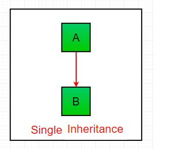

```python
# Python program for demonstrating single inheritance

# Here, we will create the base class or the Parent class
class Parent1:
    def func_1(self):
        print ("This function is defined inside the parent class.")

# now, we will create the Derived class
class Child1(Parent1):
    def func_2(self):
        print ("This function is defined inside the child class.")

# Driver's code
object = Child1()
object.func_1()
object.func_2()
```

```
This function is defined inside the parent class.
This function is defined inside the child class.
```

# Multiple Inheritance:

When a class can be derived from more than one base class this type of inheritance is called multiple inheritances. In multiple inheritances, all the features of the base classes are inherited into the derived class.

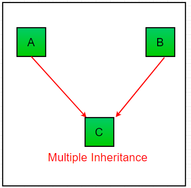

```python
# Python program for demonstrating multiple inheritance


# Here, we will create the Base class 1
class Mother1:
    mothername1 = ""
    def mother1(self):
        print(self.mothername1)

# Here, we will create the Base class 2
class Father1:
    fathername1 = ""
    def father1(self):
        print(self.fathername1)

# now, we will create the Derived class
class Son1(Mother1, Father1):
    def parents1(self):
        print ("Father name is :", self.fathername1)
        print ("Mother name is :", self.mothername1)

# Driver's code
s1 = Son1()
s1.fathername1 = "Rajesh"
s1.mothername1 = "Shreya"
s1.parents1()
```

```
Father name is : Rajesh
Mother name is : Shreya
```

# Multilevel Inheritance :

In multilevel inheritance, features of the base class and the derived class are further inherited into the new derived class. This is similar to a relationship representing a child and a grandfather.

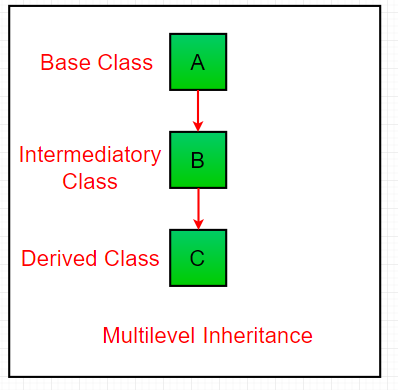

```python
# Python program for demonstrating multilevel inheritance

# Here, we will create the Base class
class Grandfather1:

    def __init__(self, grandfathername1):
        self.grandfathername1 = grandfathername1

# here, we will create the Intermediate class
class Father1(Grandfather1):
    def __init__(self, fathername1, grandfathername1):
        self.fathername1 = fathername1

        # here, we will invoke the constructor of Grandfather class
        Grandfather1.__init__(self, grandfathername1)

# here, we will create the Derived class
class Son1(Father1):
    def __init__(self,sonname1, fathername1, grandfathername1):
        self.sonname1 = sonname1

        # here, we will invoke the constructor of Father class
        Father1.__init__(self, fathername1, grandfathername1)

    def print_name(self):
        print('Grandfather name is :', self.grandfathername1)
        print("Father name is :", self.fathername1)
        print("Son name is :", self.sonname1)

# Driver code
s1 = Son1('John', 'John Jr', 'John Jr Jr')
print (s1.grandfathername1)
s1.print_name()
```

```
John Jr Jr
Grandfather name is : John Jr Jr
Father name is : John Jr
Son name is : John
```

# Hierarchical Inheritance:

When more than one derived class are created from a single base this type of inheritance is called hierarchical inheritance. In this program, we have a parent (base) class and two child (derived) classes.

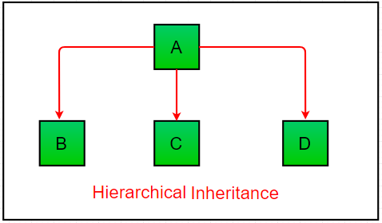

```python
# Python program for demonstrating Hierarchical inheritance

# Here, we will create the Base class
class Parent1:

    def func_1(self):
        print ("This function is defined inside the parent class.")

# Derived class1
class Child_1(Parent1):
    def func_2(self):
        print ("This function is defined inside the child 1.")

# Derivied class2
class Child_2(Parent1):
    def func_3(self):
        print ("This function is defined inside the child 2.")

# Driver's code
object1 = Child_1()
object2 = Child_2()
object1.func_1()
object1.func_2()
object2.func_1()
object2.func_3()
```

```
This function is defined inside the parent class.
This function is defined inside the child 1.
This function is defined inside the parent class.
This function is defined inside the child 2.
```